# Analysis of Temperature Trends in Wisconsin Counties (2000-2024)

2026-06-05

## **Background**

### **Data Sources**

The data used for this project comes from Tutiempo Network, S.L., an online climate data provider that compiles meteorological information from national and international weather stations.

- **Milwaukee station:** https://en.tutiempo.net/climate/ws-726405.html
- **Dane county station:** https://en.tutiempo.net/climate/ws-726410.html

Tutiempo sources its data primarily from the NOAA Global Surface Summary of the Day (GSOD) and other official meteorological archives. The platform aggregates daily measurements recorded by weather stations, which are then processed into monthly and annual summaries. Each station records temperature, precipitation, wind speed, and related atmospheric variables using standardized instruments consistent with World Meteorological Organization (WMO) protocols. The reported averages are computed from daily temperature readings collected continuously throughout each year.

### **Variables**

- **Year:** Calendar year of the observation period (2000–2024).
- **City:** The reporting weather station location (Milwaukee and Dane County).
- **Average Annual Temperature (°C):** The mean of daily temperature readings for that year at each city’s station. This is the primary variable of interest used to measure climate trends.

### **Data Structure and Sample Size**

- **Single Row Representation:** One row in the dataset represents one city-year combination—for example, the average annual temperature recorded in Milwaukee, WI for the year 2015.
- **Sample Size:** With two counties over 25 years (2000–2024 inclusive), the dataset contains approximately 50 observations (2 × 25 = 50 rows).
- **Unusual Factors:** In both our Milwaukee and Dane County data set, there are two annual temperature values missing in 2002 and 2005.

```r
# Import and Clean Data
dane <- read_csv("../data/dane_weather.csv")
milwaukee <- read_csv("../data/milwaukee_weather.csv")

# Combine for visualization and analysis
combined <- bind_rows(
  dane %>% mutate(City = "Dane County"),
  milwaukee %>% mutate(City = "Milwaukee")
)

# Remove missing values if necessary (though models handle NA usually)
combined <- combined %>% filter(!is.na(Temperature))
```

## **Visualization**

We use a Scatter Plot to compare the temperature averages from 2000 to 2024 in Milwaukee and Dane County. This graph evaluates the impact of climate change in Wisconsin depending on the trend of cooling or heating found.

- **X-axis:** Year (2000 to 2024).
- **Y-axis:** Average Annual Temperature (°C).
- **Legend:** Color coded to distinguish between Milwaukee and Dane County.
- **Trend Lines:** Dashed lines represent the linear regression fit for each city.

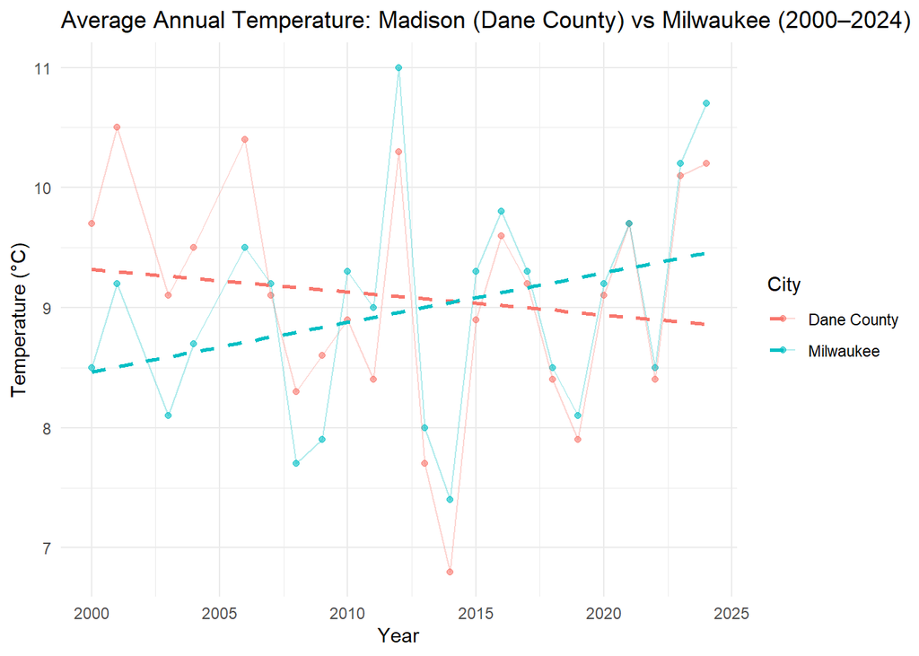

## **Statistical Analysis**

We employ simple linear regression to examine how the continuous explanatory variable (Year) influences the continuous response variable (Average Annual Temperature).

## **1. Individual Linear Models (Manual vs LM)**

We first analyze the trends for each county independently.

### **Dane County**

```r
# DANE COUNTY
x_d = dane$Year
y_d = dane$Temperature

# Manual calculation of coefficients
r_d = cor(x_d,y_d, use = "complete.obs")
beta_1_hat_d = r_d*(sd(y_d, na.rm=TRUE)/sd(x_d, na.rm=TRUE))
beta_0_hat_d = mean(y_d, na.rm=TRUE) - beta_1_hat_d * mean(x_d, na.rm=TRUE)
c(Slope = beta_1_hat_d, Intercept = beta_0_hat_d)
```

```
##       Slope   Intercept
## -0.01891231 47.14381302
```

```r
# Linear Model
model_dane <- lm(Temperature ~ Year, data = dane)
summary(model_dane)
```

```
##
## Call:
## lm(formula = Temperature ~ Year, data = dane)
##
## Residuals:
##     Min      1Q  Median      3Q     Max
## -2.2544 -0.5639 -0.0868  0.6807  1.3347
##
## Coefficients:
##             Estimate Std. Error t value Pr(>|t|)
## (Intercept) 47.14381   56.96824   0.828    0.417
## Year        -0.01891    0.02830  -0.668    0.511
##
## Residual standard error: 0.955 on 21 degrees of freedom
## Multiple R-squared:  0.02082,    Adjusted R-squared:  -0.02581
## F-statistic: 0.4465 on 1 and 21 DF,  p-value: 0.5113
```

### **Milwaukee**

```r
# MILWAUKEE
x_m = milwaukee$Year
y_m = milwaukee$Temperature

# Manual calculation of coefficients
r_m = cor(x_m,y_m, use = "complete.obs")
beta_1_hat_m = r_m*(sd(y_m, na.rm=TRUE)/sd(x_m, na.rm=TRUE))
beta_0_hat_m = mean(y_m, na.rm=TRUE) - beta_1_hat_m * mean(x_m, na.rm=TRUE)
c(Slope = beta_1_hat_m, Intercept = beta_0_hat_m)
```

```
##        Slope    Intercept
##   0.04123892 -74.01189276
```

```r
# Linear Model
model_milwaukee <- lm(Temperature ~ Year, data = milwaukee)
summary(model_milwaukee)
```

```
##
## Call:
## lm(formula = Temperature ~ Year, data = milwaukee)
##
## Residuals:
##      Min       1Q   Median       3Q      Max
## -1.64330 -0.79073  0.08042  0.55980  2.03918
##
## Coefficients:
##              Estimate Std. Error t value Pr(>|t|)
## (Intercept) -74.01189   53.80196  -1.376    0.183
## Year          0.04124    0.02673   1.543    0.138
##
## Residual standard error: 0.9019 on 21 degrees of freedom
## Multiple R-squared:  0.1018, Adjusted R-squared:  0.05903
## F-statistic:  2.38 on 1 and 21 DF,  p-value: 0.1378
```

## **2. Residual Analysis**

To ensure our linear models are valid, we check the assumptions of linearity, normality, and constant variance. **Dane County Residuals:**

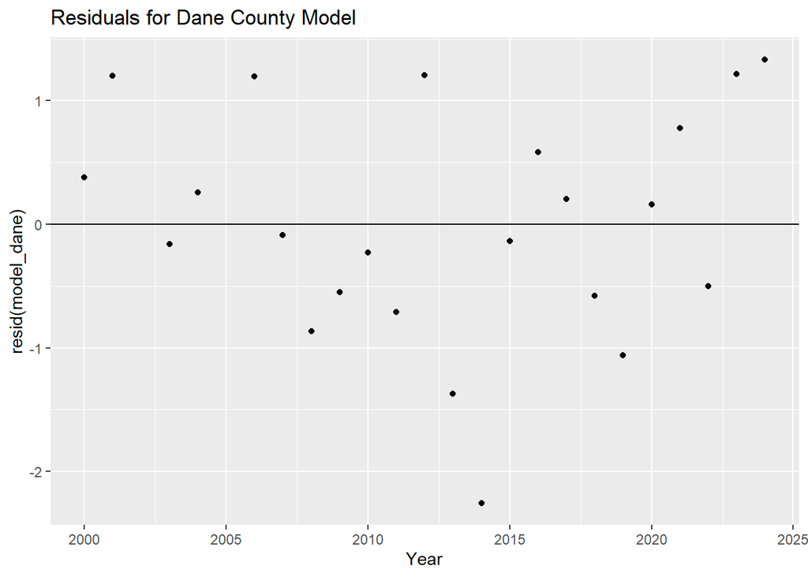

```r
dane_r_p <- ggplot(dane %>% filter(!is.na(Temperature)), aes(Year, y = resid(model_dane))) +
  geom_point() +
  geom_hline(yintercept = 0) +
  labs(title = "Residuals for Dane County Model")
dane_r_p
```

- **Linearity:** The residuals do not show a curved pattern and appear randomly scattered around zero.
- **Normality:** Most residuals cluster near zero with no extreme outliers.
- **Constant Variance:** The spread remains consistent across years.

**Milwaukee Residuals:**

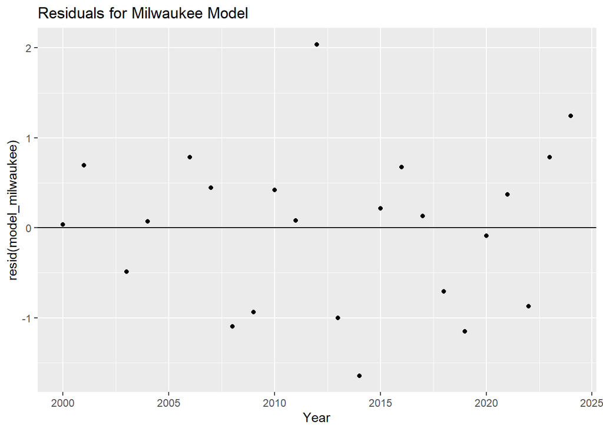

```r
milwaukee_r_p <- ggplot(milwaukee %>% filter(!is.na(Temperature)), aes(Year, y = resid(model_milwaukee))) +
  geom_point() +
  geom_hline(yintercept = 0) +
  labs(title = "Residuals for Milwaukee Model")
milwaukee_r_p
```

- **Linearity:** Residuals are scattered randomly around zero.
- **Normality:** Residuals stay near zero with no extreme outliers.
- **Constant Variance:** The vertical spread is stable across years.

**Conclusion:** Regression assumptions appear satisfied for both models.

## **3. Formal Test for Difference in Trends**

To address the research question of whether the temperature change differs between the two counties, we fit an interaction model. We test the null hypothesis $H_0 : \beta_{Year:Milwaukee} = 0$ , which assumes the slope of the regression line is the same for both cities.

```r
# Interaction model to compare slopes
model_interaction <- lm(Temperature ~ Year * City, data = combined)
summary(model_interaction)$coefficients
```

```
##                         Estimate  Std. Error    t value  Pr(>|t|)
## (Intercept)          47.14381302 55.40772231  0.8508528 0.3996761
## Year                 -0.01891231  0.02752835 -0.6870123 0.4958511
## CityMilwaukee      -121.15570577 78.35835235 -1.5461747 0.1295650
## Year:CityMilwaukee    0.06015124  0.03893096  1.5450745 0.1298306
```

The interaction term Year:CityMilwaukee represents the difference in the rate of temperature change between Milwaukee and Dane County.

## **4. Confidence and Prediction Intervals**

### **Confidence Intervals for Slope (Rate of Change)**

```r
# DANE
se_d = summary(model_dane)$coefficients[2, 2]
n_d = nrow(dane %>% filter(!is.na(Temperature)))
moe_d = qt(0.975,n_d-2)*se_d
left_d = beta_1_hat_d - moe_d
right_d = beta_1_hat_d + moe_d
cat("Dane Slope 95% CI: [", left_d, ", ", right_d, "]\n")
```

```
## Dane Slope 95% CI: [ -0.077773 ,  0.03994838 ]
```

```r
# MILWAUKEE
se_m = summary(model_milwaukee)$coefficients[2, 2]
n_m = nrow(milwaukee %>% filter(!is.na(Temperature)))
moe_m = qt(0.975,n_m-2)*se_m
left_m = beta_1_hat_m - moe_m
right_m = beta_1_hat_m + moe_m
cat("Milwaukee Slope 95% CI: [", left_m, ", ", right_m, "]\n")
```

```
## Milwaukee Slope 95% CI: [ -0.01435031 ,  0.09682815 ]
```

### **Prediction Intervals (2020-2024)**

```r
# Predictions for Dane
intervals_d = predict(model_dane, newdata = tibble(Year = 2020:2024), interval = "prediction")
head(intervals_d)
```

```
##        fit      lwr      upr
## 1 8.940941 6.867697 11.01418
## 2 8.922029 6.835856 11.00820
## 3 8.903116 6.802445 11.00379
## 4 8.884204 6.767495 11.00091
## 5 8.865292 6.731042 10.99954
```

```r
# Predictions for Milwaukee
intervals_m = predict(model_milwaukee, newdata = tibble(Year = 2020:2024), interval = "prediction")
head(intervals_m)
```

```
##        fit      lwr      upr
## 1 9.290735 7.332721 11.24875
## 2 9.331974 7.361750 11.30220
## 3 9.373213 7.389296 11.35713
## 4 9.414452 7.415389 11.41351
## 5 9.455690 7.440062 11.47132
```

## **Discussion**

### **Shortcomings**

Time Span: 24 years is a relatively short period for climate analysis. Short-term weather variability (like El Niño/La Niña cycles) can often mask true long-term climate trends. Missing Data: Data for the years 2002 and 2005 were missing from the source files. While the model can handle missing rows, having a complete time series would improve precision. Urban Heat Island: Both datasets represent urban centers. It is possible that urban development in both cities is driving temperature changes that confound the natural “lake effect” we attempted to isolate.

### **Future Research**

Future research should expand the dataset to cover at least 50 to 100 years to better distinguish climate trends from annual weather noise. Additionally, including rural control sites for both counties would help isolate the true impact of Lake Michigan by removing the confounding variable of urbanization and heat islands.